# Populism in Pan-American Politics

Jackson R. Mandel

2025-04-09

# Introduction

- Central Question: Does the average viable political party in the Americas engage in more populist rhetoric than the average viable political party in other countries?
- Motivation:
  - Understanding political dynamics unique to the Americas
  - Uncovering structural similarities between Anglo-American and Latin American political systems
- Conclusion: Although the average populism score of pan-American parties was higher than the rest of the world, the difference was not statistically significant.

# Data

- Drawn from the V-Dem (Varieties of Democracy)V-Party database
- v2xpa_popul: a measure of populist rhetoric by a political party
  - Aggregate of a score of anti-elite rhetoric and rhetoric identifying “the people” as a homogenous sovereign interest group
- v2paseatshare: the share of seats in parliament at the last election
  - Used to filter out parties with less than 10% of seats
- country_name: used to create a new variable identifying if a country is in the Americas

# Comparing Populist Rhetoric

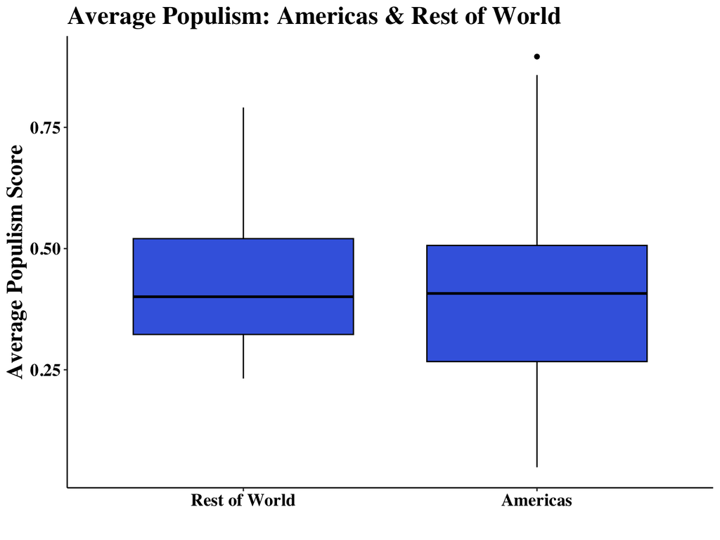

# Difference of Means Test

- Null Hypothesis: The average viable political party in the Americas does not use more populist rhetoric than the average political party in the rest of the world.
  - Result: failure to reject the null hypothesis

```
##
##  Welch Two Sample t-test
##
## data:  average_populism by is_americas
## t = 0.6691, df = 37.648, p-value = 0.5075
## alternative hypothesis: true difference in means between group Americas and group Other is not equal to 0
## 95 percent confidence interval:
##  -0.04331925  0.08607277
## sample estimates:
## mean in group Americas    mean in group Other
##              0.4250132              0.4036364
```